# Dog Breed Classification

This notebook lists all the steps that you need to complete the complete this project. You will need to complete all the TODOs in this notebook as well as in the README and the two python scripts included with the starter code.

**Note:** This notebook has a bunch of code and markdown cells with TODOs that you have to complete. These are meant to be helpful guidelines for you to finish your project while meeting the requirements in the project rubrics. Feel free to change the order of these the TODO's and use more than one TODO code cell to do all your tasks.

```python
# TODO: Install any packages that you might need
# For instance, you will need the smdebug package
!pip install smdebug
!pip install torch
!pip install torchvision
```

[output not shown]

```python
# TODO: Import any packages that you might need
# For instance you will need Boto3 and Sagemaker
import argparse
import sagemaker
import smdebug
import boto3
import base64
import json
from PIL import Image
import io
from sagemaker.pytorch import PyTorch
from sagemaker.pytorch.model import PyTorchModel
from sagemaker.tuner import (
    IntegerParameter,
    CategoricalParameter,
    ContinuousParameter,
    HyperparameterTuner,
)
from sagemaker.debugger import (
    Rule,
    ProfilerRule,
    DebuggerHookConfig,
    rule_configs,
    ProfilerConfig,
    FrameworkProfile
)

from smdebug.trials import create_trial
from smdebug.core.modes import ModeKeys
import matplotlib.pyplot as plt
from mpl_toolkits.axes_grid1 import host_subplot
from smdebug.profiler.analysis.notebook_utils.training_job import TrainingJob
from smdebug.profiler.analysis.notebook_utils.timeline_charts import TimelineCharts
import IPython
import os
role =  'arn:aws:iam::154013814934:role/service-role/AmazonSageMaker-ExecutionRole-20221230T151109' #sagemaker.get_execution_role() #
```

```
[2023-01-18 13:01:06.628 1-8-1-cpu-py36-ml-t3-medium-05a4a7868130c7575335c53b16c7:33 INFO utils.py:27] RULE_JOB_STOP_SIGNAL_FILENAME: None
```

```python
role
```

```
'arn:aws:iam::154013814934:role/service-role/AmazonSageMaker-ExecutionRole-20221230T151109'
```

## Dataset

```python
#TODO: Fetch and upload the data to AWS S3

# Command to download and unzip data
!wget https://s3-us-west-1.amazonaws.com/udacity-aind/dog-project/dogImages.zip
```

[output not shown]

```python
!unzip dogImages.zip
```

[output not shown]

[output cut: 8700 more lines]

[output not shown]

```python
bucket_name = 'dogbreedclassificationudacity'
```

```python
!aws s3 sync --only-show-errors ./dogImages/train s3://dogbreedclassificationudacity/train/
!aws s3 sync --only-show-errors ./dogImages/valid s3://dogbreedclassificationudacity/valid/
```

```python
!aws s3 sync --only-show-errors ./dogImages/test s3://dogbreedclassificationudacity/test/
```

## testing main function

```python
import hpo
```

```python
import train_model
```

```python
import importlib
```

```python
importlib.reload(train_model)
```

```
<module 'train_model' from '/root/CD0387-deep-learning-topics-within-computer-vision-nlp-project-starter/train_model.py'>
```

```python
importlib.reload(hpo)
```

```
<module 'hpo' from '/root/CD0387-deep-learning-topics-within-computer-vision-nlp-project-starter/hpo.py'>
```

```python
class Namespace:
    def __init__(self, **kwargs):
        self.__dict__.update(kwargs)
```

```python
args = Namespace(batch_size = 128, test_batch_size = 1000, epochs = 2, lr = 0.01)
```

```python
args.batch_size
```

```
128
```

```python
train_model.main()
```

[output not shown]

[output cut: 14 more lines]

[output not shown]

```python
hpo.main(args)
```

```
Defining Device:
cuda:0
Loading Model
Sending Model to Device
Epoch 0, Phase train
Epoch 0, Phase valid
Epoch 1, Phase train
Epoch 1, Phase valid
Testing Model on Whole Testing Dataset
Testing Accuracy: 504704912.08133966, Testing Loss: 1.401298464324817e-45
```

## Hyperparameter Tuning

**TODO:** This is the part where you will finetune a pretrained model with hyperparameter tuning. Remember that you have to tune a minimum of two hyperparameters. However you are encouraged to tune more. You are also encouraged to explain why you chose to tune those particular hyperparameters and the ranges.

I chose to tune lr (learning rate), batch_size, and epochs, because they seemed to me like they would have the largest impact on training speed and accuracy. I kept the epochs range rather small in order to avoid large cost accumulation during the course of this project. </br>

**Note:** You will need to use the `hpo.py` script to perform hyperparameter tuning.

```python
#TODO: Create estimators for your HPs

estimator = PyTorch(
    entry_point="hpo.py",
    role=role,
    py_version='py36',
    framework_version="1.8",
    instance_count=1,
    instance_type="ml.g4dn.xlarge",
)
```

```python
hyperparameter_ranges = {
    "lr": ContinuousParameter(0.0001, 0.1),
    "batch_size": CategoricalParameter([32, 64, 128, 256, 512]),
    "epochs": CategoricalParameter([1,2,3,4])
}
```

```python
objective_metric_name = "average test loss"
objective_type = "Minimize"
metric_definitions = [{"Name": "average test loss", "Regex": "Test set: Average loss: ([0-9\\.]+)"}]
```

```python
tuner = HyperparameterTuner(
    estimator,
    objective_metric_name,
    hyperparameter_ranges,
    metric_definitions,
    max_jobs=4,
    max_parallel_jobs=2,
    objective_type=objective_type
)
```

```python
# TODO: Fit your HP Tuner
tuner.fit(wait = True) # TODO: Remember to include your data channels
```

```
............................................................................................................................................................................................................................................................................................................…
```

```python
tuner.best_training_job()
```

```
'pytorch-training-230116-2139-004-d6c1370e'
```

```python
# TODO: Get the best estimators and the best HPs

best_estimator = tuner.best_estimator()

#Get the hyperparameters of the best trained model
best_estimator.hyperparameters()
```

```
2023-01-16 22:02:45 Starting - Found matching resource for reuse
2023-01-16 22:02:45 Downloading - Downloading input data
2023-01-16 22:02:45 Training - Training image download completed. Training in progress.
2023-01-16 22:02:45 Uploading - Uploading generated training model
2023-01-16 22:02:45 Completed - Resource retained for reuse
```

```
{'_tuning_objective_metric': '"average test loss"',
 'batch_size': '"256"',
 'epochs': '"4"',
 'lr': '0.0037606895378491374',
 'sagemaker_container_log_level': '20',
 'sagemaker_estimator_class_name': '"PyTorch"',
 'sagemaker_estimator_module': '"sagemaker.pytorch.estimator"',
 'sagemaker_job_name': '"pytorch-training-2023-01-16-21-39-13-436"',
 'sagemaker_program': '"hpo.py"',
 'sagemaker_region': '"us-east-1"',
 'sagemaker_submit_directory': '"s3://sagemaker-us-east-1-154013814934/pytorch-training-2023-01-16-21-39-13-436/source/sourcedir.tar.gz"'}
```

## Model Profiling and Debugging

TODO: Using the best hyperparameters, create and finetune a new model

**Note:** You will need to use the `train_model.py` script to perform model profiling and debugging.

```python
rules = [
    Rule.sagemaker(rule_configs.vanishing_gradient()),
    Rule.sagemaker(rule_configs.overfit()),
    Rule.sagemaker(rule_configs.overtraining()),
    Rule.sagemaker(rule_configs.poor_weight_initialization()),
    Rule.sagemaker(rule_configs.loss_not_decreasing()),
    ProfilerRule.sagemaker(rule_configs.LowGPUUtilization()),
    ProfilerRule.sagemaker(rule_configs.ProfilerReport())
]
```

```python
debugger_config = DebuggerHookConfig(
    hook_parameters={"train.save_interval": "100", "eval.save_interval": "10"}
)
profiler_config = ProfilerConfig(
    system_monitor_interval_millis=500, framework_profile_params=FrameworkProfile(num_steps=10)
)
```

```python
hyperparameters = {"epochs": "4", "batch_size": "256", "lr": '0.0037606895378491374'}
```

```python
estimator = PyTorch(
    entry_point="train_model.py",
    base_job_name="dogbreedclassification-pytorch",
    role = role,
    instance_count=1,
    instance_type="ml.g4dn.xlarge",
    hyperparameters=hyperparameters,
    framework_version="1.8",
    py_version="py36",
    ## Debugger and Profiler Parameters
    rules=rules,
    debugger_hook_config=debugger_config,
    profiler_config = profiler_config
)
```

```python
estimator.fit(wait = True)
```

[output not shown]

[output cut: 112 more lines]

```
Overtraining: Error
PoorWeightInitialization: IssuesFound
LossNotDecreasing: InProgress
Epoch 1, Phase valid
Epoch 2, Phase train
Epoch 2, Phase valid
Epoch 3, Phase train
Epoch 3, Phase valid
Downloading: "https://download.pytorch.org/models/resnet50-19c8e357.pth" to /root/.cache/torch/hub/checkpoints/resnet50-19c8e357.pth
2023-01-18 13:22:45,452 sagemaker-training-toolkit INFO     Reporting training SUCCESS

2023-01-18 13:23:14 Uploading - Uploading generated training model
2023-01-18 13:23:14 Completed - Training job completed
Training seconds: 1016
Billable seconds: 1016
```

```python
job_name = estimator.latest_training_job.name
client = estimator.sagemaker_session.sagemaker_client
description = client.describe_training_job(TrainingJobName=estimator.latest_training_job.name)
```

```python
job_name
```

```
'dogbreedclassification-pytorch-2023-01-18-13-04-51-108'
```

```python
client
```

```
<botocore.client.SageMaker at 0x7f5c8c073e48>
```

```python
description
```

[output not shown]

[output cut: 92 more lines]

[output not shown]

```python
estimator.latest_job_debugger_artifacts_path()
```

```
's3://sagemaker-us-east-1-154013814934/dogbreedclassification-pytorch-2023-01-18-13-04-51-108/debug-output'
```

## Analysis of Debugging Output

```python
# Code borrowed from Udacity's model_profileing.ipynb
session = boto3.session.Session()
region = session.region_name

training_job_name = estimator.latest_training_job.name
print(f"Training jobname: {training_job_name}")
print(f"Region: {region}")

trial = create_trial(estimator.latest_job_debugger_artifacts_path())

print(trial.tensor_names())
print(len(trial.tensor("CrossEntropyLoss_output_0").steps(mode=ModeKeys.TRAIN)))
print(len(trial.tensor("CrossEntropyLoss_output_0").steps(mode=ModeKeys.EVAL)))

tj = TrainingJob(training_job_name, region)
tj.wait_for_sys_profiling_data_to_be_available()

system_metrics_reader = tj.get_systems_metrics_reader()
system_metrics_reader.refresh_event_file_list()

view_timeline_charts = TimelineCharts(
    system_metrics_reader,
    framework_metrics_reader=None,
    select_dimensions=["CPU", "GPU"],
    select_events=["total"],
)

rule_output_path = estimator.output_path + estimator.latest_training_job.job_name + "/rule-output"
print(f"You will find the profiler report in {rule_output_path}")

! aws s3 ls {rule_output_path} --recursive
! aws s3 cp {rule_output_path} ./ --recursive

# get the autogenerated folder name of profiler report
profiler_report_name = [
    rule["RuleConfigurationName"]
    for rule in estimator.latest_training_job.rule_job_summary()
    if "Profiler" in rule["RuleConfigurationName"]
][0]

IPython.display.HTML(filename=profiler_report_name + "/profiler-output/profiler-report.html")
```

```
Training jobname: dogbreedclassification-pytorch-2023-01-18-13-04-51-108
Region: us-east-1
[2023-01-18 13:25:03.559 1-8-1-cpu-py36-ml-t3-medium-05a4a7868130c7575335c53b16c7:33 INFO s3_trial.py:42] Loading trial debug-output at path s3://sagemaker-us-east-1-154013814934/dogbreedclassification-pytorch-2023-01-18-13-04-51-108/debug-output
[2023-01-18 13:25:04.021 1-8-1-cpu-py36-ml-t3-medium-05a4a7868130c7575335c53b16c7:33 INFO trial.py:198] Training has ended, will refresh one final time in 1 sec.
[2023-01-18 13:25:05.047 1-8-1-cpu-py36-ml-t3-medium-05a4a7868130c7575335c53b16c7:33 INFO trial.py:210] Loaded all steps
['CrossEntropyLoss_output_0', 'gradient/ResNet_fc.0.bias', 'gradient/ResNet_fc.0.weight', 'layer1.0.relu_input_0', 'layer1.0.relu_input_1', 'layer1.0.relu_input_2', 'layer1.1.relu_input_0', 'layer1.1.relu_input_1', 'layer1.1.relu_input_2', 'layer1.2.relu_input_0', 'layer1.2.relu_input_1', 'layer1.2.…
1
1
ProfilerConfig:{'S3OutputPath': 's3://sagemaker-us-east-1-154013814934/', 'ProfilingIntervalInMilliseconds': 500, 'ProfilingParameters': {'DataloaderProfilingConfig': '{"StartStep": 0, "NumSteps": 10, "MetricsRegex": ".*", }', 'DetailedProfilingConfig': '{"StartStep": 0, "NumSteps": 10, }', 'FileOpe…
s3 path:s3://sagemaker-us-east-1-154013814934/dogbreedclassification-pytorch-2023-01-18-13-04-51-108/profiler-output


Profiler data from system is available
[2023-01-18 13:25:05.235 1-8-1-cpu-py36-ml-t3-medium-05a4a7868130c7575335c53b16c7:33 INFO metrics_reader_base.py:134] Getting 17 event files
select events:['total']
select dimensions:['CPU', 'GPU']
filtered_events:{'total'}
filtered_dimensions:{'GPUMemoryUtilization-nodeid:algo-1', 'GPUUtilization-nodeid:algo-1', 'CPUUtilization-nodeid:algo-1'}
```

[interactive chart not shown]

[output not shown]

SageMaker Debugger Profiling Report

SageMaker Debugger auto generated this report. You can generate similar reports on all supported training jobs. The report provides summary of training job, system resource usage statistics, framework metrics, rules summary, and detailed analysis from each rule. The graphs and tables are interactive.

**Legal disclaimer:** This report and any recommendations are provided for informational purposes only and are not definitive. You are responsible for making your own independent assessment of the information.

```
# Parameters
processing_job_arn = "arn:aws:sagemaker:us-east-1:154013814934:processing-job/dogbreedclassification-pyt-profilerreport-82f446bc"
```

Training job summary

[interactive chart not shown]

System usage statistics

[interactive chart not shown]

Framework metrics summary

[interactive chart not shown]

Overview: CPU operators

[interactive chart not shown]

Rules summary

The following table shows a profiling summary of the Debugger built-in rules. The table is sorted by the rules that triggered the most frequently. During your training job, the GPUMemoryIncrease rule was the most frequently triggered. It processed 1878 datapoints and was triggered 16 times.

|  | Description | Recommendation | Number of times rule triggered | Number of datapoints | Rule parameters |
| --- | --- | --- | --- | --- | --- |
| GPUMemoryIncrease | Measures the average GPU memory footprint and triggers if there is a large increase. | Choose a larger instance type with more memory if footprint is close to maximum available memory. | 16 | 1878 | increase:5 patience:1000 window:10 |
| LowGPUUtilization | Checks if the GPU utilization is low or fluctuating. This can happen due to bottlenecks, blocking calls for synchronizations, or a small batch size. | Check if there are bottlenecks, minimize blocking calls, change distributed training strategy, or increase the batch size. | 8 | 1878 | threshold_p95:70 threshold_p5:10 window:500 patience:1000 |
| BatchSize | Checks if GPUs are underutilized because the batch size is too small. To detect this problem, the rule analyzes the average GPU memory footprint, the CPU and the GPU utilization. | The batch size is too small, and GPUs are underutilized. Consider running on a smaller instance type or increasing the batch size. | 8 | 1877 | cpu_threshold_p95:70 gpu_threshold_p95:70 gpu_memory_threshold_p95:70 patience:1000 window:500 |
| Dataloader | Checks how many data loaders are running in parallel and whether the total number is equal the number of available CPU cores. The rule triggers if number is much smaller or larger than the number of a… | Change the number of data loader processes. | 1 | 15 | min_threshold:70 max_threshold:200 |
| StepOutlier | Detects outliers in step duration. The step duration for forward and backward pass should be roughly the same throughout the training. If there are significant outliers, it may indicate a system stall… | Check if there are any bottlenecks (CPU, I/O) correlated to the step outliers. | 0 | 25 | threshold:3 mode:None n_outliers:10 stddev:3 |
| IOBottleneck | Checks if the data I/O wait time is high and the GPU utilization is low. It might indicate IO bottlenecks where GPU is waiting for data to arrive from storage. The rule evaluates the I/O and GPU utili… | Pre-fetch data or choose different file formats, such as binary formats that improve I/O performance. | 0 | 1881 | threshold:50 io_threshold:50 gpu_threshold:10 patience:1000 |
| MaxInitializationTime | Checks if the time spent on initialization exceeds a threshold percent of the total training time. The rule waits until the first step of training loop starts. The initialization can take longer if do… | Initialization takes too long. If using File mode, consider switching to Pipe mode in case you are using TensorFlow framework. | 0 | 25 | threshold:20 |
| CPUBottleneck | Checks if the CPU utilization is high and the GPU utilization is low. It might indicate CPU bottlenecks, where the GPUs are waiting for data to arrive from the CPUs. The rule evaluates the CPU and GPU… | Consider increasing the number of data loaders or applying data pre-fetching. | 0 | 1881 | threshold:50 cpu_threshold:90 gpu_threshold:10 patience:1000 |
| LoadBalancing | Detects workload balancing issues across GPUs. Workload imbalance can occur in training jobs with data parallelism. The gradients are accumulated on a primary GPU, and this GPU might be overused with … | Choose a different distributed training strategy or a different distributed training framework. | 0 | 1878 | threshold:0.2 patience:1000 |

Analyzing the training loop

Step duration analysis

[interactive chart not shown]

GPU utilization analysis

**Usage per GPU**

[interactive chart not shown]

**GPU utilization of gpu0 on node algo-1:**

[interactive chart not shown]

**Workload balancing**

[interactive chart not shown]

Dataloading analysis

[interactive chart not shown]

Batch size

[interactive chart not shown]

CPU bottlenecks

[interactive chart not shown]

I/O bottlenecks

[interactive chart not shown]

GPU memory

[interactive chart not shown]

**Memory utilization of gpu0 on node algo-1:**

[interactive chart not shown]

[figure not shown]

**TODO**: Is there some anomalous behaviour in your debugging output? If so, what is the error and how will you fix it? </br> It does seem like there is anomalous behavior in my debugging output. Some examples are below.

1. I have an overfitting error. Overfitting can be fixed in a few ways. I can decrease the size of my network down from a resnet50 to a resnet 18, for example. I can also augment the data that I'm using for the project.</br>
2. I have low GPU utilization. I could avoid this in the future by either increasing batch size or using a smaller instance. </br>

## Model Deploying

```python
from sagemaker.model_monitor import DataCaptureConfig
from sagemaker.serializers import JSONSerializer
from sagemaker.deserializers import JSONDeserializer
```

```python
trained_model = PyTorchModel(model_data = 's3://sagemaker-us-east-1-154013814934/dogbreedclassification-pytorch-2023-01-18-13-04-51-108/output/model.tar.gz',
                             role = role,
                             entry_point = 'inference.py',
                             framework_version = '1.8',
                             py_version = 'py36',
                             source_dir = 'code/')
```

```python
data_capture_config = DataCaptureConfig(
  destination_s3_uri = "s3://sagemaker-us-east-1-154013814934/data_capture/",
  enable_capture = True
)
predictor=trained_model.deploy(role = role,
                           initial_instance_count = 1,
                           data_capture_config = data_capture_config,
                           instance_type = 'ml.t2.medium',
                           serializer=JSONSerializer(),
                           deserializer=JSONDeserializer())
```

```
------------!
```

```python
tmp_name = 'dogImages/valid/007.American_foxhound/American_foxhound_00526.jpg'
data = {}
with open(tmp_name, "rb") as image_file:
    image = base64.b64encode(image_file.read())

data['inputs'] = base64.encodebytes(image).decode('ascii')
```

```python
imageStream = io.BytesIO(base64.b64decode(base64.decodebytes(data['inputs'].encode('ascii'))))
test_image2 = Image.open(imageStream)
```

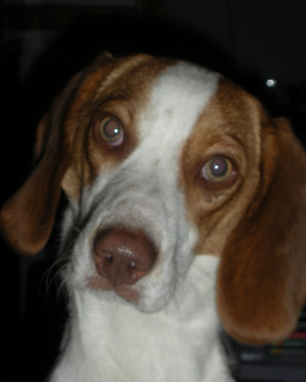

```python
test_image2
```

```python
# TODO: Run an prediction on the endpoint

#image = # TODO: Your code to load and preprocess image to send to endpoint for prediction
response = predictor.predict(data)
```

```python
len(response[0])
```

```
133
```

```python
response
```

```
[[-8.44900894165039,
  -6.76777982711792,
  -5.57310152053833,
  -2.573413610458374,
  -9.345908164978027,
  -8.872673988342285,
  5.129315376281738,
  -0.8739115595817566,
  -4.04814338684082,
  -4.544404983520508,
  -4.700314044952393,
  -4.047562599182129,
  -3.575589418411255,
  1.9461194276809692,
  -2.8994791507720947,
  3.3558602333068848,
  -7.13115930557251,
  -5.412714004516602,
  -6.468892574310303,
  -5.145796298980713,
  -9.712895393371582,
  -11.241738319396973,
  -6.021214485168457,
  -8.626444816589355,
  -4.4801740646362305,
  -8.697810173034668,
  -2.910519599914551,
  -1.1547939777374268,
  -5.922508239746094,
  -2.792123317718506,
  -5.951056003570557,
  -4.899544715881348,
  -6.249343395233154,
  -3.634546995162964,
  -5.645223140716553,
  -5.572770595550537,
  4.153204917907715,
  -5.709435939788818,
  -4.333207130432129,
  -6.797924995422363,
```

[output cut: 78 more lines]

```
  -6.037464141845703,
  -5.262271881103516,
  -1.7198973894119263,
  1.695621371269226,
  -7.383270263671875,
  -4.387049198150635,
  -5.825894355773926,
  -5.5930352210998535,
  -4.9922895431518555,
  0.06007085740566254,
  -4.9661335945129395,
  -2.2716615200042725,
  -1.8981273174285889,
  -3.0969369411468506,
  -8.34217643737793]]
```

```python
# TODO: Remember to shutdown/delete your endpoint once your work is done
predictor.delete_endpoint()
```